# statistics

*solution_03_central_limit_theorem/02_normal/08_x_from_rightarea_v2*

First, draw a sketch. We can label the $K$ axis by adding integer multiples of 18 to 79. We know to shade the right because high values of $K$ satisfy the condition $K>k$ (regardless of the exact value of $k$). We don’t know exactly where to place the boundary, but we know the right area is 0.81.

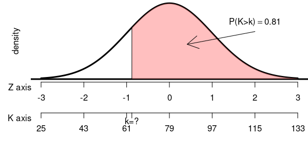

We know how to find the left area.
$$\begin{aligned}
P(K<k) &= 1-P(K>k) \\
&= 1-0.81 \\
&= 0.19
\end{aligned}$$

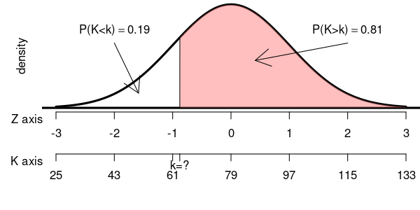

As an intermediate step, we find $z$ such that $P(Z<z)=0.19$.

By using the $z$ table we can determine $z$.

[output not shown]

Either -0.88 or -0.87 is a good estimation of $z$, and either value will lead you to an acceptable answer. Using other tools, a more accurate value can be found. I will show the work with a more accurate value.
$$z=-0.8779$$

We now convert the $z$ score into a $k$ score.
$$\begin{aligned}
k &= \mu+z\sigma \\
&= 79+(-0.8779)(18) \\
&= 63.2
\end{aligned}$$

We can also visualize this with a spinner.

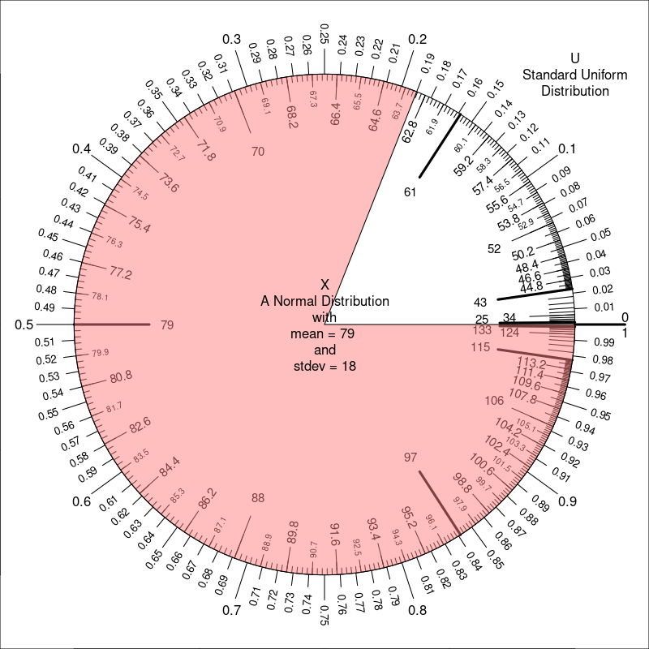

The tolerance for an acceptable answer was $\pm 1$ from 63.1978667. So, anything between 62.1978667 and 64.1978667 was accepted.